# Vagus in PMR: Bloodchemistry

```r
load(file = "C://R/Vagal Tone in PMR/RData/data-bloodchemistry.RData")
library(tidyverse)
```

Lad os se et lille udsnit af data. Indtil videre er datasættet samlet fra de to sheets, og så har jeg lavet hhv. en long og wide udgave.

# Dataframe (df) i long format

```r
df.cytokines
```

| subject_id | visit_number | visit_type | angio_bfgf | angio_flt1 | angio_plgf | angio_tie2 | angio_vegfc | angio_vegfd | angio_eotaxin | chemo_eotaxin3 | chemo_ip10 | chemo_mcp1 | chemo_mcp4 | chemo_mdc | chemo_mip1a | chemo_mip1b | chemo_tarc | cyto_il15 | cyto_il16 | cyto_il17a | cyto_il1a | cyto_il5 | cyto_il7 | cyto_tnfb | cyto_vegf | pro_ifny | pro_il10 | pro_il13 | pro_il1b | … |
| --- | --- | --- | --- | --- | --- | --- | --- | --- | --- | --- | --- | --- | --- | --- | --- | --- | --- | --- | --- | --- | --- | --- | --- | --- | --- | --- | --- | --- | --- | --- |
| 3 | 1 | Baseline | NA | NA | 0.159433 | 19.48476 | 4.313609 | 2.116312 | 163.20662 | 5.556748 | 645.1069 | 137.50740 | 161.54333 | 765.1938 | NA | 80.38362 | 238.05418 | NA | 316.4200 | 38.6379151 | NA | NA | 23.364811 | NA | 20.63842 | 4.6308057 | 0.279768415 | 0.2650990 | 0.163344500 | … |
| 3 | 3 | Day 5 | 0.084405 | 0.5946905 | 0.159433 | 19.48476 | 4.313609 | 2.116312 | 170.25497 | NA | 656.5762 | 142.71924 | 130.77888 | 780.2976 | 14.50030 | 71.52720 | 201.27151 | 2.609349 | 265.4379 | 1.9204269 | 0.05090657 | NA | 10.009616 | 0.04296547 | 18.83383 | 6.8827651 | 0.324915362 | 0.2650990 | 0.165418558 | … |
| 4 | 1 | Baseline | NA | NA | 0.159433 | 19.48476 | 4.313609 | 2.116312 | 115.12686 | 6.810540 | 782.9069 | 108.17986 | 94.57986 | 702.3014 | 15.62164 | 83.70369 | 211.09213 | 2.218571 | 571.4939 | 2.3083904 | NA | 0.01266923 | 9.617457 | 0.06946303 | 128.09349 | 4.9810991 | 0.273437550 | 0.2650990 | NA | … |
| 4 | 3 | Day 5 | 0.084405 | NA | NA | NA | NA | 2.116312 | 72.99596 | NA | 613.3416 | 118.95788 | 82.89014 | 681.7966 | NA | 69.09672 | 188.20182 | 1.996025 | 316.4598 | 2.2573097 | 5.35713860 | 0.01266923 | 12.879113 | 0.12447497 | 148.25759 | 5.9621875 | 0.178438225 | 0.8024321 | 0.125401216 | … |
| 5 | 1 | Baseline | 4.183236 | 81.2505668 | 14.393873 | 3964.36938 | 411.586784 | 1484.348194 | 283.10287 | 19.186178 | 923.4679 | 332.11433 | 122.39040 | 609.2010 | 19.03798 | 116.17370 | 343.47905 | 2.235202 | 217.6801 | 1.9592621 | 0.05090657 | 1.48114860 | 12.417955 | 0.07260159 | 142.01432 | 11.5092350 | 0.530906844 | 0.2650990 | 0.007877764 | … |
| 5 | 3 | Day 5 | 52.890788 | 94.7061572 | 16.821926 | 4209.32297 | 625.347075 | 1906.403490 | 400.23323 | 33.959820 | 1009.6374 | 396.64804 | 205.95017 | 666.3925 | 286.35830 | 563.24443 | 611.55756 | 2.076277 | 428.0149 | 1.1726616 | 0.05090657 | 2.02063973 | 8.891729 | 0.07796666 | 299.42587 | 12.7853533 | 1.145052524 | NA | 5.525643902 | … |
| 6 | 1 | Baseline | 47.806139 | 57.5108793 | 13.196268 | 3299.69817 | 76.689405 | 732.637302 | 154.06836 | NA | 1156.2198 | 102.28352 | NA | 738.0141 | NA | 87.20688 | 158.17555 | NA | 172.0227 | NA | NA | NA | NA | NA | 17.18789 | 7.2258206 | 0.641224053 | 0.2650990 | 0.002532774 | … |
| 6 | 3 | Day 5 | 108.497112 | 76.1261260 | 13.810906 | 3461.00252 | 274.972167 | 774.407063 | 251.38257 | NA | 939.5521 | 79.03266 | 264.96794 | 833.8024 | NA | 133.67487 | 283.64673 | NA | NA | NA | 0.05090657 | NA | NA | NA | NA | 6.4967552 | 0.527688961 | 0.2650990 | NA | … |
| 7 | 1 | Baseline | 32.778925 | 172.0583427 | 11.733456 | 4867.37596 | 584.326977 | 1604.260517 | 247.20429 | 14.557372 | 697.0223 | 375.15521 | 377.06040 | 1021.5104 | 14.37751 | 202.87404 | 584.58104 | 3.198576 | 296.3529 | 0.6306135 | 0.05090657 | 0.08204690 | 23.258844 | 0.07259811 | 175.99113 | 2.4991073 | 0.139622237 | 0.2650990 | 0.007877764 | … |
| 7 | 3 | Day 5 | 10.733048 | 203.5564883 | 10.957545 | 4962.50116 | 295.406379 | 1423.986153 | 134.71353 | 8.364970 | 574.0084 | 201.19308 | 136.66320 | 749.4019 | 14.84784 | 123.65476 | 129.05487 | 3.164126 | 352.1528 | 0.5739295 | 0.05090657 | 0.10979697 | 4.755722 | 0.08603373 | 87.92615 | 2.5395442 | 0.126061529 | 0.2650990 | 0.007877764 | … |

[output cut: 20 more lines]

# Dataframe i wide format

```r
df.cytokines.WIDE
```

| subject_id | angio_bfgf_1 | angio_bfgf_3 | angio_flt1_1 | angio_flt1_3 | angio_plgf_1 | angio_plgf_3 | angio_tie2_1 | angio_tie2_3 | angio_vegfc_1 | angio_vegfc_3 | angio_vegfd_1 | angio_vegfd_3 | angio_eotaxin_1 | angio_eotaxin_3 | chemo_eotaxin3_1 | chemo_eotaxin3_3 | chemo_ip10_1 | chemo_ip10_3 | chemo_mcp1_1 | chemo_mcp1_3 | chemo_mcp4_1 | chemo_mcp4_3 | chemo_mdc_1 | chemo_mdc_3 | chemo_mip1a_1 | chemo_mip1a_3 | chemo_mip1b_1 | chemo_mip1b_3 | chemo_tarc_1 | … |
| --- | --- | --- | --- | --- | --- | --- | --- | --- | --- | --- | --- | --- | --- | --- | --- | --- | --- | --- | --- | --- | --- | --- | --- | --- | --- | --- | --- | --- | --- | --- |
| 3 | NA | 0.084405 | NA | 0.5946905 | 0.159433 | 0.159433 | 19.48476 | 19.48476 | 4.313609 | 4.313609 | 2.116312 | 2.116312 | 163.2066 | 170.25497 | 5.556748 | NA | 645.1069 | 656.5762 | 137.5074 | 142.71924 | 161.54333 | 130.77888 | 765.1938 | 780.2976 | NA | 14.50030 | 80.38362 | 71.52720 | 238.05418 | … |
| 4 | NA | 0.084405 | NA | NA | 0.159433 | NA | 19.48476 | NA | 4.313609 | NA | 2.116312 | 2.116312 | 115.1269 | 72.99596 | 6.810540 | NA | 782.9069 | 613.3416 | 108.1799 | 118.95788 | 94.57986 | 82.89014 | 702.3014 | 681.7966 | 15.62164 | NA | 83.70369 | 69.09672 | 211.09213 | … |
| 5 | 4.183236 | 52.890788 | 81.25057 | 94.7061572 | 14.393873 | 16.821926 | 3964.36938 | 4209.32297 | 411.586784 | 625.347075 | 1484.348194 | 1906.403490 | 283.1029 | 400.23323 | 19.186178 | 33.95982 | 923.4679 | 1009.6374 | 332.1143 | 396.64804 | 122.39040 | 205.95017 | 609.2010 | 666.3925 | 19.03798 | 286.35830 | 116.17370 | 563.24443 | 343.47905 | … |
| 6 | 47.806139 | 108.497112 | 57.51088 | 76.1261260 | 13.196268 | 13.810906 | 3299.69817 | 3461.00252 | 76.689405 | 274.972167 | 732.637302 | 774.407063 | 154.0684 | 251.38257 | NA | NA | 1156.2198 | 939.5521 | 102.2835 | 79.03266 | NA | 264.96794 | 738.0141 | 833.8024 | NA | NA | 87.20688 | 133.67487 | 158.17555 | … |
| 7 | 32.778925 | 10.733048 | 172.05834 | 203.5564883 | 11.733456 | 10.957545 | 4867.37596 | 4962.50116 | 584.326977 | 295.406379 | 1604.260517 | 1423.986153 | 247.2043 | 134.71353 | 14.557372 | 8.36497 | 697.0223 | 574.0084 | 375.1552 | 201.19308 | 377.06040 | 136.66320 | 1021.5104 | 749.4019 | 14.37751 | 14.84784 | 202.87404 | 123.65476 | 584.58104 | … |
| 8 | 34.158530 | NA | 140.82123 | NA | 13.225295 | NA | 3559.35218 | NA | 509.643159 | NA | 927.275264 | NA | 246.0456 | NA | 20.341508 | NA | 778.9861 | NA | 350.3328 | NA | 222.87580 | NA | 840.4753 | NA | 21.88313 | NA | 185.30509 | NA | 217.68211 | … |
| 9 | 7.096514 | 9.355224 | 130.98984 | 129.0773890 | 14.892030 | 15.792184 | 3882.75010 | 4094.87410 | 479.434277 | 565.955948 | 1403.391515 | 1514.430777 | 276.9494 | 318.65005 | 18.801932 | 22.30862 | 879.3401 | 924.6507 | 321.6805 | 329.71885 | 167.64651 | 204.43643 | 1000.0946 | 1039.0849 | 22.88887 | 22.95333 | 135.83693 | 130.92312 | 271.89240 | … |
| 10 | 20.548930 | 71.786533 | 86.41620 | 98.7894989 | 11.631517 | 12.220337 | 4049.89311 | 3975.79086 | 774.085654 | 801.362257 | 1953.936877 | 2029.815033 | 312.9423 | 346.20057 | 24.444965 | 16.87501 | 462.3822 | 472.5272 | 225.2112 | 277.38742 | 210.51511 | 226.39458 | 1493.4465 | 1573.7884 | 16.36282 | 19.09731 | 176.92106 | 202.64081 | 678.42762 | … |
| 12 | 1.860742 | 2.552682 | 145.59861 | 132.5782092 | 10.756428 | 9.764848 | 4219.56994 | 4123.21416 | 293.914875 | 510.402693 | 1045.261473 | 931.875708 | 209.4522 | 277.10170 | 15.159709 | 25.17228 | 523.8017 | 626.4006 | 231.3689 | 276.36678 | 65.64575 | 112.08464 | 1735.3293 | 1872.6386 | 13.04050 | 14.57931 | 85.63620 | 122.56950 | 181.26049 | … |
| 13 | NA | 27.370154 | NA | 134.7934426 | 10.757959 | 13.535718 | 3899.99468 | 3873.65102 | 558.462649 | 512.986291 | NA | 1319.486960 | NA | 269.20770 | 13.794914 | 10.13143 | NA | 1217.3183 | 275.5042 | 249.98108 | NA | 154.87648 | 965.8463 | 586.9002 | NA | 16.96044 | 108.43671 | 129.64239 | NA | … |

[output cut: 5 more lines]

Eftersom vi skal udføre parrede t-tests på forskellene i mellem visits, skal vi have udregnet forskellene. DELTA_ vars er lavet med et ordentlig stykke manuelt arbejde, desværre. Jeg skal nok få loop’et den engang.

# Dataframe over forskelle

```r
# MANUELT ARBEJDE ----
## Denne proces involverer brug af regneark.
## Delta cytokin-værdier
df.cytokines.WIDE <- df.cytokines.WIDE %>% mutate(
  DELTA_angio_bfgf = angio_bfgf_3 - angio_bfgf_1,
  DELTA_angio_flt1 = angio_flt1_3 - angio_flt1_1,
  DELTA_angio_plgf = angio_plgf_3 - angio_plgf_1,
  DELTA_angio_tie2 = angio_tie2_3 - angio_tie2_1,
  DELTA_angio_vegfc = angio_vegfc_3 - angio_vegfc_1,
  DELTA_angio_vegfd = angio_vegfd_3 - angio_vegfd_1,
  DELTA_angio_eotaxin = angio_eotaxin_3 - angio_eotaxin_1,
  DELTA_chemo_eotaxin3 = chemo_eotaxin3_3 - chemo_eotaxin3_1,
  DELTA_chemo_ip10 = chemo_ip10_3 - chemo_ip10_1,
  DELTA_chemo_mcp1 = chemo_mcp1_3 - chemo_mcp1_1,
  DELTA_chemo_mcp4 = chemo_mcp4_3 - chemo_mcp4_1,
  DELTA_chemo_mdc = chemo_mdc_3 - chemo_mdc_1,
  DELTA_chemo_mip1a = chemo_mip1a_3 - chemo_mip1a_1,
  DELTA_chemo_mip1b = chemo_mip1b_3 - chemo_mip1b_1,
  DELTA_chemo_tarc = chemo_tarc_3 - chemo_tarc_1,
  DELTA_cyto_il15 = cyto_il15_3 - cyto_il15_1,
  DELTA_cyto_il16 = cyto_il16_3 - cyto_il16_1,
  DELTA_cyto_il17a = cyto_il17a_3 - cyto_il17a_1,
  DELTA_cyto_il1a = cyto_il1a_3 - cyto_il1a_1,
  DELTA_cyto_il5 = cyto_il5_3 - cyto_il5_1,
  DELTA_cyto_il7 = cyto_il7_3 - cyto_il7_1,
  DELTA_cyto_tnfb = cyto_tnfb_3 - cyto_tnfb_1,
  DELTA_cyto_vegf = cyto_vegf_3 - cyto_vegf_1,
  DELTA_pro_ifny = pro_ifny_3 - pro_ifny_1,
  DELTA_pro_il10 = pro_il10_3 - pro_il10_1,
  DELTA_pro_il13 = pro_il13_3 - pro_il13_1,
  DELTA_pro_il1b = pro_il1b_3 - pro_il1b_1,
  DELTA_pro_il2 = pro_il2_3 - pro_il2_1,
  DELTA_pro_il4 = pro_il4_3 - pro_il4_1,
  DELTA_pro_il6 = pro_il6_3 - pro_il6_1,
  DELTA_pro_il8 = pro_il8_3 - pro_il8_1,
  DELTA_pro_tnfa = pro_tnfa_3 - pro_tnfa_1,
  DELTA_vasc_crp = vasc_crp_3 - vasc_crp_1,
  DELTA_vasc_sicam1 = vasc_sicam1_3 - vasc_sicam1_1,
  DELTA_vasc_svcam1 = vasc_svcam1_3 - vasc_svcam1_1,
  DELTA_vasc_saa = vasc_saa_3 - vasc_saa_1,

)

df.cytokines.WIDE[c(1, (grep("^DELTA_", colnames(df.cytokines.WIDE))))]
```

| subject_id | DELTA_angio_bfgf | DELTA_angio_flt1 | DELTA_angio_plgf | DELTA_angio_tie2 | DELTA_angio_vegfc | DELTA_angio_vegfd | DELTA_angio_eotaxin | DELTA_chemo_eotaxin3 | DELTA_chemo_ip10 | DELTA_chemo_mcp1 | DELTA_chemo_mcp4 | DELTA_chemo_mdc | DELTA_chemo_mip1a | DELTA_chemo_mip1b | DELTA_chemo_tarc | DELTA_cyto_il15 | DELTA_cyto_il16 | DELTA_cyto_il17a | DELTA_cyto_il1a | DELTA_cyto_il5 | DELTA_cyto_il7 | DELTA_cyto_tnfb | DELTA_cyto_vegf | DELTA_pro_ifny | DELTA_pro_il10 | DELTA_pro_il13 | DELTA_pro_il1b | DELTA_pro_il2 | DELTA_pro_il4 | … |
| --- | --- | --- | --- | --- | --- | --- | --- | --- | --- | --- | --- | --- | --- | --- | --- | --- | --- | --- | --- | --- | --- | --- | --- | --- | --- | --- | --- | --- | --- | --- |
| 3 | NA | NA | 0.0000000 | 0.00000 | 0.000000 | 0.000000 | 7.0483498 | NA | 11.46928 | 5.211843 | -30.764452 | 15.10381 | NA | -8.856418 | -36.78267 | NA | -50.982091 | -36.71748815 | NA | NA | -13.35519582 | NA | -1.804598 | 2.25195933 | 0.045146948 | 0.00000000 | 0.002074057 | 0.08780620 | 0.010825832 | … |
| 4 | NA | NA | NA | NA | NA | 0.000000 | -42.1309053 | NA | -169.56527 | 10.778017 | -11.689712 | -20.50475 | NA | -14.606973 | -22.89031 | -0.22254659 | -255.034151 | -0.05108069 | NA | 0.000000000 | 3.26165660 | 0.055011937 | 20.164096 | 0.98108848 | -0.094999326 | 0.53733314 | NA | 0.03220141 | NA | … |
| 5 | 48.7075528 | 13.455590 | 2.4280524 | 244.95359 | 213.760291 | 422.055296 | 117.1303610 | 14.773641221 | 86.16954 | 64.533714 | 83.559769 | 57.19143 | 267.32031913 | 447.070738 | 268.07852 | -0.15892413 | 210.334739 | -0.78660052 | 0.000000000 | 0.539491125 | -3.52622504 | 0.005365064 | 157.411550 | 1.27611830 | 0.614145680 | NA | 5.517766138 | NA | NA | … |
| 6 | 60.6909738 | 18.615247 | 0.6146379 | 161.30435 | 198.282762 | 41.769760 | 97.3142081 | NA | -216.66772 | -23.250860 | NA | 95.78825 | NA | 46.467996 | 125.47118 | NA | NA | NA | NA | NA | NA | NA | NA | -0.72906542 | -0.113535092 | 0.00000000 | NA | NA | 0.000000000 | … |
| 7 | -22.0458772 | 31.498146 | -0.7759116 | 95.12520 | -288.920599 | -180.274364 | -112.4907605 | -6.192402129 | -123.01388 | -173.962129 | -240.397209 | -272.10854 | 0.47033225 | -79.219274 | -455.52617 | -0.03445033 | 55.799917 | -0.05668395 | 0.000000000 | 0.027750066 | -18.50312174 | 0.013435617 | -88.064986 | 0.04043688 | -0.013560708 | 0.00000000 | 0.000000000 | 0.00000000 | NA | … |
| 8 | NA | NA | NA | NA | NA | NA | NA | NA | NA | NA | NA | NA | NA | NA | NA | NA | NA | NA | NA | NA | NA | NA | NA | NA | NA | NA | NA | NA | NA | … |
| 9 | 2.2587092 | -1.912455 | 0.9001532 | 212.12400 | 86.521672 | 111.039262 | 41.7006207 | 3.506693228 | 45.31062 | 8.038343 | 36.789923 | 38.99035 | 0.06445673 | -4.913808 | 34.60223 | -0.25807763 | 40.877163 | 0.57568293 | 0.000000000 | -0.045795408 | 2.07440387 | 0.000000000 | 54.085031 | 6.34258033 | 0.350706477 | 0.00000000 | NA | NA | NA | … |
| 10 | 51.2376029 | 12.373298 | 0.5888196 | -74.10226 | 27.276603 | 75.878156 | 33.2582258 | -7.569954718 | 10.14504 | 52.176220 | 15.879470 | 80.34189 | 2.73448602 | 25.719753 | -17.49494 | -0.19346611 | -74.982238 | -0.52157421 | 0.000000000 | 0.054561932 | -0.58983788 | -0.012562748 | 15.679400 | -1.31488093 | -0.005665129 | 0.00000000 | 0.098014314 | 0.12899733 | -0.001758475 | … |
| 12 | 0.6919395 | -13.020397 | -0.9915796 | -96.35578 | 216.487818 | -113.385765 | 67.6494816 | 10.012568362 | 102.59886 | 44.997873 | 46.438882 | 137.30937 | 1.53880626 | 36.933301 | 305.58883 | -0.08839124 | -130.011254 | -0.37316766 | 0.000000000 | NA | 3.82238380 | -0.017851237 | 53.984473 | -0.37238484 | 0.052303206 | 0.00000000 | 0.000000000 | NA | -0.020515102 | … |
| 13 | NA | NA | 2.7777593 | -26.34366 | -45.476358 | NA | NA | -3.663483902 | NA | -25.523143 | NA | -378.94608 | NA | 21.205683 | NA | NA | NA | -1.38511096 | -0.006192273 | NA | -0.03873647 | NA | NA | -2.54490327 | NA | 0.01094924 | NA | NA | NA | … |

[output cut: 5 more lines]

Desværre ses der en del manglende data. Det er umiddel et hullet datasæt.

# Test for Normality

Lad os teste for normalfordelte data. Først kan vi bruge Shapiro Wilks test. Her må Christina ENDELIG ytre sig om variansen.

```r
# vars.DELTA
vars.DELTA <- df.cytokines.WIDE[grep("^DELTA_", colnames(df.cytokines.WIDE))]

# vars.DELTA for each panel
vars.DELTA.angio <- vars.DELTA[grep("angio_", colnames(vars.DELTA))]
vars.DELTA.chemo <- vars.DELTA[grep("chemo_", colnames(vars.DELTA))]
vars.DELTA.cyto <- vars.DELTA[grep("cyto_", colnames(vars.DELTA))]
vars.DELTA.pro <- vars.DELTA[grep("pro_", colnames(vars.DELTA))]
vars.DELTA.vasc <- vars.DELTA[grep("vasc_", colnames(vars.DELTA))]

# # Shapiro-Wilk test of Normality
# lapply(
#   vars.DELTA,
#   function(x) shapiro.test(x))
```

## Shapiro Wilk

### Angiogenesis panel

```r
lapply(
  vars.DELTA.angio,
  function(x) shapiro.test(x))
```

```
$DELTA_angio_bfgf

    Shapiro-Wilk normality test

data:  x
W = 0.87508, p-value = 0.09005


$DELTA_angio_flt1

    Shapiro-Wilk normality test

data:  x
W = 0.87015, p-value = 0.07787


$DELTA_angio_plgf

    Shapiro-Wilk normality test

data:  x
W = 0.91755, p-value = 0.2324


$DELTA_angio_tie2

    Shapiro-Wilk normality test

data:  x
W = 0.78599, p-value = 0.004669


$DELTA_angio_vegfc

    Shapiro-Wilk normality test

data:  x
W = 0.95162, p-value = 0.6231


$DELTA_angio_vegfd

    Shapiro-Wilk normality test

data:  x
W = 0.91505, p-value = 0.215


$DELTA_angio_eotaxin

    Shapiro-Wilk normality test

data:  x
W = 0.96218, p-value = 0.7869
```

Fraset tie2 er data normalfordelte.

### Chemokine panel

```r
lapply(
  vars.DELTA.chemo,
  function(x) shapiro.test(x))
```

```
$DELTA_chemo_eotaxin3

    Shapiro-Wilk normality test

data:  x
W = 0.931, p-value = 0.5594


$DELTA_chemo_ip10

    Shapiro-Wilk normality test

data:  x
W = 0.93732, p-value = 0.4232


$DELTA_chemo_mcp1

    Shapiro-Wilk normality test

data:  x
W = 0.90388, p-value = 0.1284


$DELTA_chemo_mcp4

    Shapiro-Wilk normality test

data:  x
W = 0.744, p-value = 0.002315


$DELTA_chemo_mdc

    Shapiro-Wilk normality test

data:  x
W = 0.86895, p-value = 0.04056


$DELTA_chemo_mip1a

    Shapiro-Wilk normality test

data:  x
W = 0.45126, p-value = 2.65e-06


$DELTA_chemo_mip1b

    Shapiro-Wilk normality test

data:  x
W = 0.53055, p-value = 1.039e-05


$DELTA_chemo_tarc

    Shapiro-Wilk normality test

data:  x
W = 0.85691, p-value = 0.03509
```

En blanding af normalfordelte og ikke-normalfordelte data.

### Cytokine panel

```r
lapply(
  vars.DELTA.cyto,
  function(x) shapiro.test(x))
```

```
$DELTA_cyto_il15

    Shapiro-Wilk normality test

data:  x
W = 0.86818, p-value = 0.07344


$DELTA_cyto_il16

    Shapiro-Wilk normality test

data:  x
W = 0.87955, p-value = 0.08649


$DELTA_cyto_il17a

    Shapiro-Wilk normality test

data:  x
W = 0.36357, p-value = 1.098e-06


$DELTA_cyto_il1a

    Shapiro-Wilk normality test

data:  x
W = 0.36572, p-value = 1.004e-07


$DELTA_cyto_il5

    Shapiro-Wilk normality test

data:  x
W = 0.67596, p-value = 0.0007431


$DELTA_cyto_il7

    Shapiro-Wilk normality test

data:  x
W = 0.88051, p-value = 0.07246


$DELTA_cyto_tnfb

    Shapiro-Wilk normality test

data:  x
W = 0.68111, p-value = 0.001375


$DELTA_cyto_vegf

    Shapiro-Wilk normality test

data:  x
W = 0.9256, p-value = 0.3358
```

### Proinflammatory panel

```r
lapply(
  vars.DELTA.pro,
  function(x) shapiro.test(x))
```

```
$DELTA_pro_ifny

    Shapiro-Wilk normality test

data:  x
W = 0.91235, p-value = 0.1704


$DELTA_pro_il10

    Shapiro-Wilk normality test

data:  x
W = 0.75382, p-value = 0.002028


$DELTA_pro_il13

    Shapiro-Wilk normality test

data:  x
W = 0.46438, p-value = 5.498e-06


$DELTA_pro_il1b

    Shapiro-Wilk normality test

data:  x
W = 0.43215, p-value = 5.879e-07


$DELTA_pro_il2

    Shapiro-Wilk normality test

data:  x
W = 0.78903, p-value = 0.01529


```

[output cut: 15 more lines]

```

$DELTA_pro_il8

    Shapiro-Wilk normality test

data:  x
W = 0.34949, p-value = 1.669e-06


$DELTA_pro_tnfa

    Shapiro-Wilk normality test

data:  x
W = 0.59183, p-value = 3.433e-05
```

To analyser med normalfordelte data.

### Vascular injury panel

```r
lapply(
  vars.DELTA.vasc,
  function(x) shapiro.test(x))
```

```
$DELTA_vasc_crp

    Shapiro-Wilk normality test

data:  x
W = 0.91353, p-value = 0.1534


$DELTA_vasc_sicam1

    Shapiro-Wilk normality test

data:  x
W = 0.73041, p-value = 0.0005359


$DELTA_vasc_svcam1

    Shapiro-Wilk normality test

data:  x
W = 0.97561, p-value = 0.9307


$DELTA_vasc_saa

    Shapiro-Wilk normality test

data:  x
W = 0.80581, p-value = 0.01122
```

To analyse med normalfordelte data.

## QQ-plots

Lad os se lidt nærmere på data vha. QQ-plots.

Vi kan først skrive en lille smart funktion, som hjælper med at lave mange ting hurtigt.

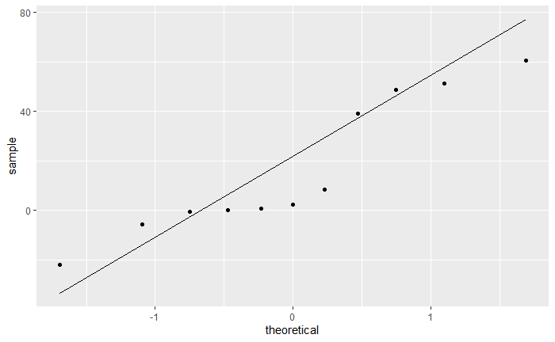

```r
f.loop <- function(x) {
  for (i in names(x)) {
    qqnorm(x[,i], main = names(x[i]))
    qqline(x[,i])
  }
}

df <- data.frame(y = rt(200, df = 5))
qq <- ggplot(vars.DELTA.angio, aes(sample = DELTA_angio_bfgf))
qq + stat_qq() + stat_qq_line()
```

### Angiogenesis panel

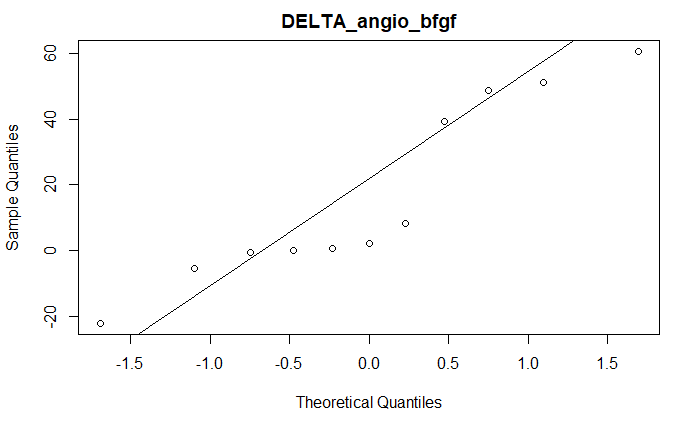

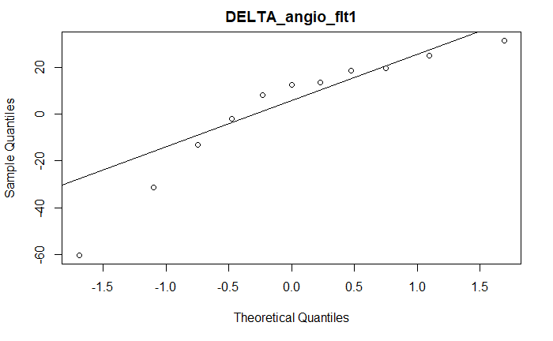

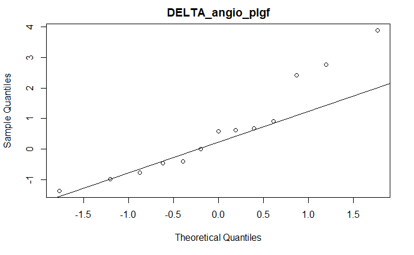

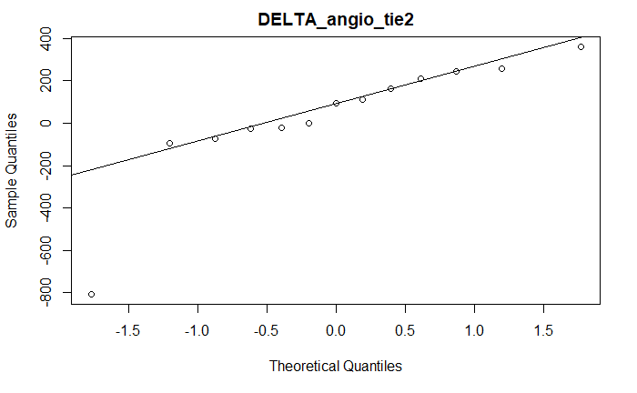

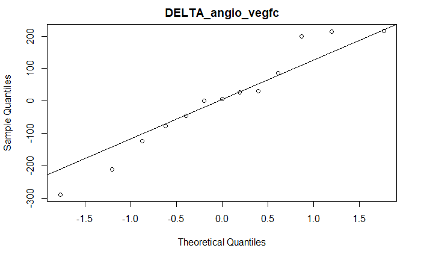

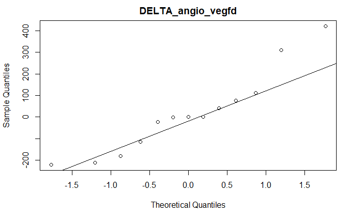

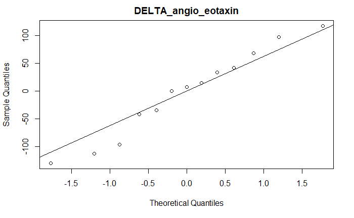

```r
f.loop(vars.DELTA.angio)
```

### Chemokine panel

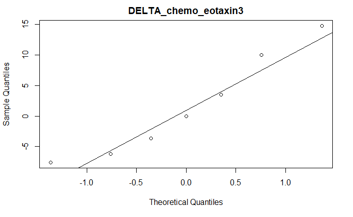

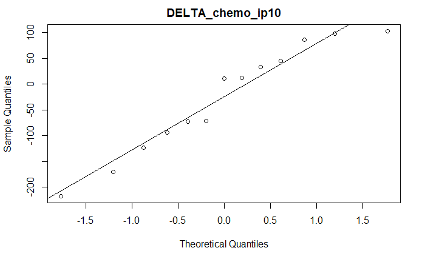

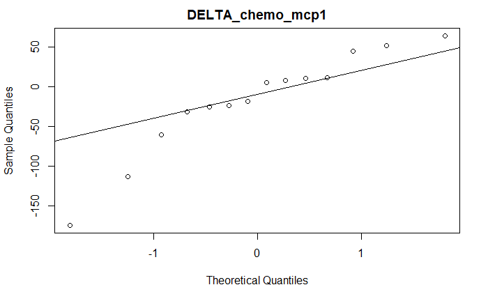

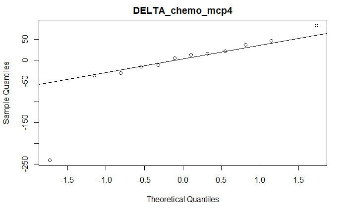

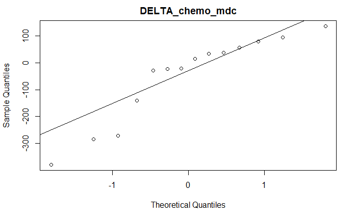

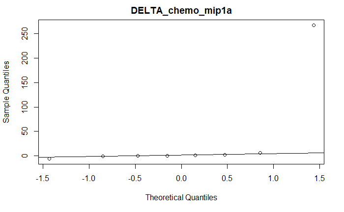

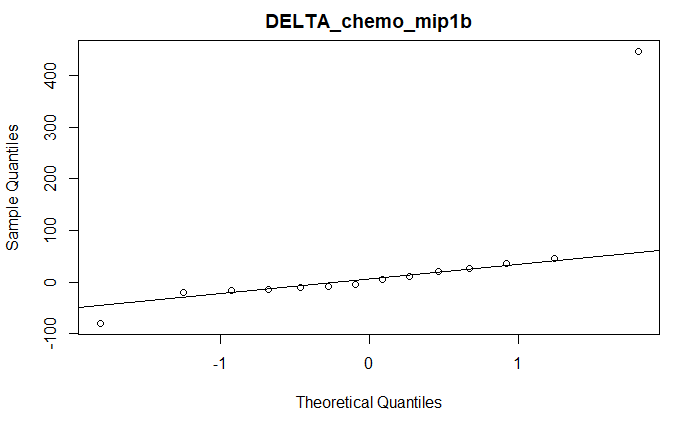

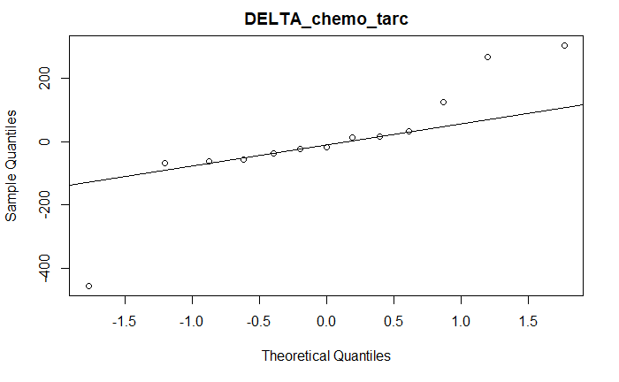

```r
f.loop(vars.DELTA.chemo)
```

### Cytokine panel

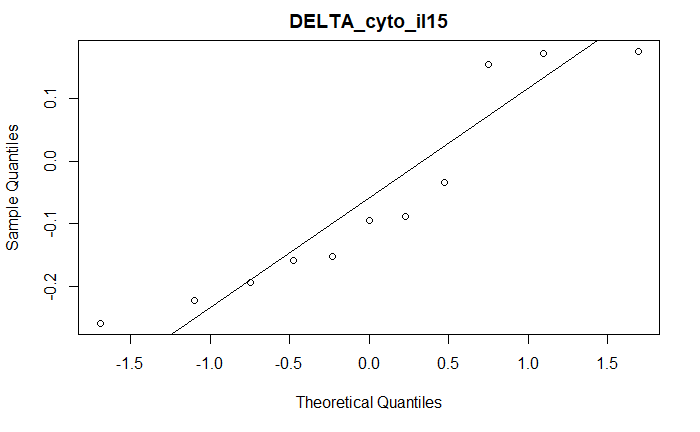

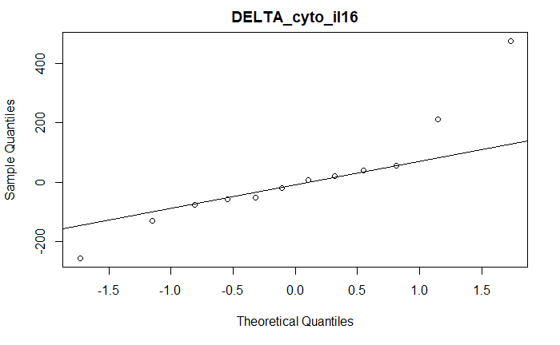

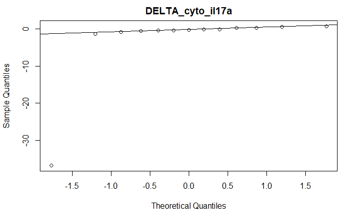

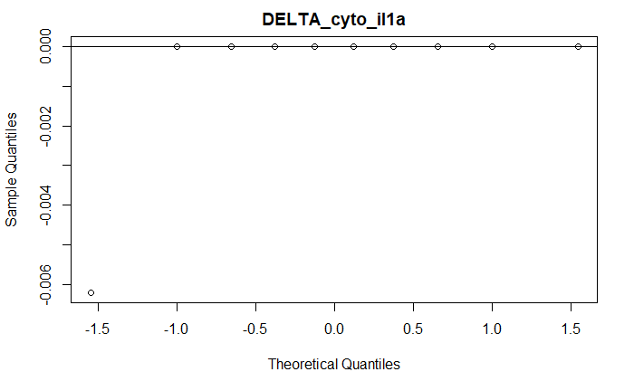

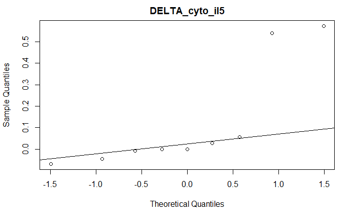

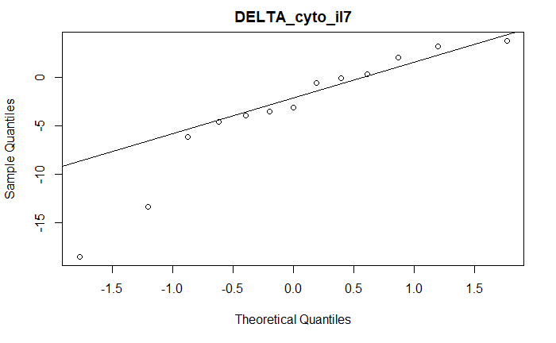

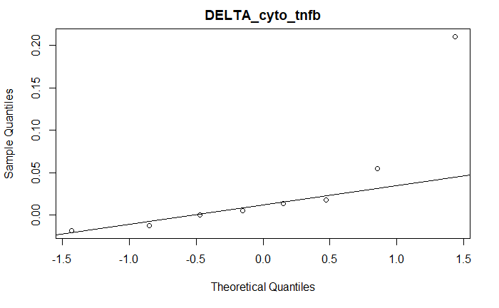

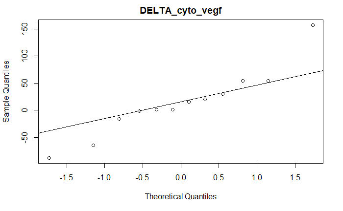

```r
f.loop(vars.DELTA.cyto)
```